# Лабораторная работа №2

Операционные системы

Репкина Е. А.

Российский университет дружбы народов, Москва, Россия

4 марта 2025

## Цель работы

Цель данной лабораторной работы – изучение идеологии и применения средств контроля версий, освоение умения по работе с git.

## Задание

1. Создать базовую конфигурацию для работы с git
2. Создать ключ SSH
3. Создать ключ GPG
4. Настроить подписи Git
5. Заргеистрироваться на GitHub
6. Создать локальный каталог для выполнения заданий по предмету.

## Выполнение лабораторной работы. Установка ПО.

Устанавливаю git(рис. [-@fig:001])

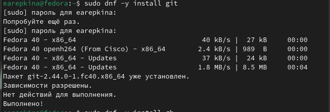

Установка

Устанавливаю gh (рис. [-@fig:002])

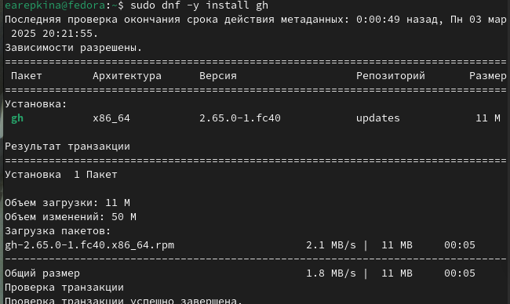

Установка gh

## Выполнение лабораторной работы. Базовая настройка git

Задаю имя и email владельца репозитория(рис. [-@fig:003])

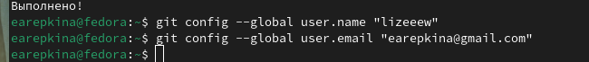

имя и email

## Выполнение лабораторной работы. Базовая настройка git

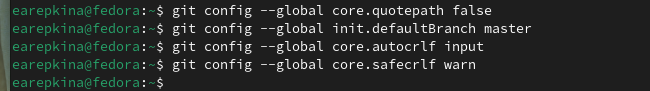

Выполнение команд

## Выполнение лабораторной работы. Создание ключа SSH

Создаю ssh ключ (рис. [-@fig:005])

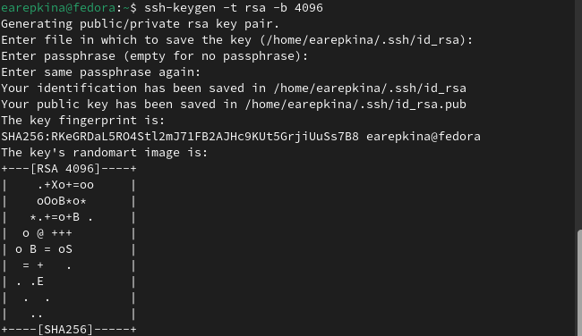

Создание ключа

## Выполнение лабораторной работы. Создание ключа GPG

Создаю ключи pgp (рис. [-@fig:006])

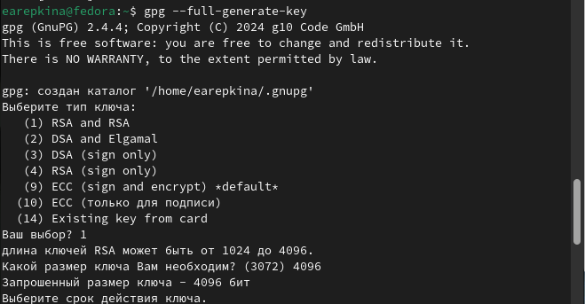

Генерирование ключа

копирую сгенерированный PGP ключ в буфер обмена (рис. [-@fig:007])

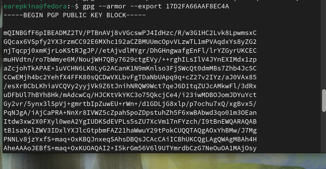

Копирование

Настраиваю gh (рис. [-@fig:008])

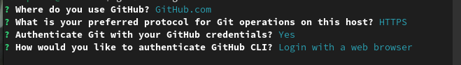

Настройка

## Выполнение лабораторной работы. Регистрация на Github

Авторизовываюсь в gh (рис. [-@fig:009])

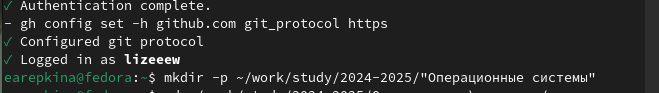

успешная авторизация

## Выполнение лабораторной работы. Создание репозитория курса на основе шаблона

Создаю репозиторий курса на основе шаблона (рис. [-@fig:010])

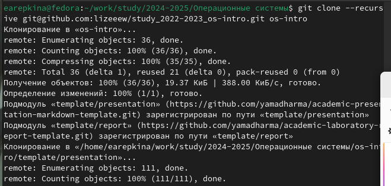

Создание репозитория

## Выполнение лабораторной работы. Создание репозитория курса на основе шаблона

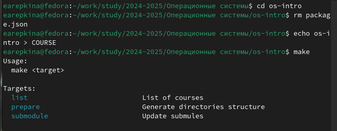

Выполнение команд

## Выполнение лабораторной работы. Создание репозитория курса на основе шаблона

Отправляю файлы на сервер (рис. [-@fig:012])

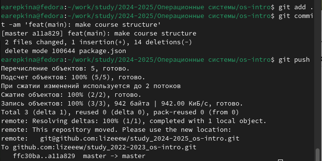

Выполнение команд

## Выводы

При выполнении данной лабораторной работы я изучила идеологию и применение средств контроля версий, освоила умение по работе с git.